# Four steps to make your plot

The package `superb` facilitates the production of summary statistic plots having adjusted error bars (Cousineau, Goulet, & Harding, 2021). Error bars are measures of precision; they are meant to convey some indications of the trust we can place in a given result. Those results that come will large error bars (wide intervals) should be considered less reliable that those with short error bars.

Error bars, which are drawn from measures of precision, comes in many flavors. There is the simple *standard error* (SE), the more famous *confidence interval* (CI), and new proposals such as the *highest density interval* (HDI). The package `superb` has build-in functions for both the SE and CI, but any other measure of precision can be added (as shown in [Vignette 4](https://dcousin3.github.io/superb/articles/Vignette4.html)).

All measures of precision are tailored for a given statistic. Hence, we have the *standard error of the mean*, the *standard error of the median*, the *confidence interval of the skew*, etc. For each and every statistic, there is a corresponding measure of precision. In what follows, we discuss the confidence interval, but everything that follows apply equally well to any measure of precision.

The basic confidence interval can be termed a “stand-alone” confidence interval because it indicates the precision of a statistic in isolation. It is useful to compare this statistics to a criterion performance or any *a priori*-determined value. As shown in [Vignette 2](https://dcousin3.github.io/superb/articles/Vignette2.html) and [Vignette 3](https://dcousin3.github.io/superb/articles/Vignette3.html), such “stand-alone” measures are inadequate when an observed result is to be compared to other observed results (also see Cousineau, 2005, 2017).

In order to use `superb`, four choices need to be made, described next. Prior to that, it is necessary to check the data format. Herein we illustrate the means with 95% confidence intervals; these can be changed, as shown in [Vignette 4](https://dcousin3.github.io/superb/articles/Vignette4.html).

## Data format

The format of the data in `superb` follows the general convention “1 subject = 1 line,” that is, all the information regarding a given participant must stand on a single line. This format is called in R the **wide format**; in SPSS, SAS and other statistics software, this is the standard data organization. Further, the data must be contained within a `data.frame` with named columns. It is easy to go from **wide format** to **long format**, with, e.g., Navarro’s `wideToLong` excellent function (Navarro, 2015).

As an illustration, we use the following ficticious data set showing the performance of 15 participants on their motivation scores on Week 1, Week 2 and Week 3 for a program to stop smoking.

```r
#Motivation data for 15 participants over three weeks in wide format:
dta <- matrix( c(
    45, 50,  59,
    47, 58,  64,
    53, 63,  72,
    57, 64,  81,
    58, 67,  86,
    61, 70,  98,
    61, 75, 104,
    63, 79, 100,
    63, 79,  84,
    71, 81,  96,
    72, 83,  82,
    74, 84,  82,
    76, 86,  93,
    84, 90,  85,
    90, 96,  89
), ncol=3, byrow=T)

# put column names then convert to data.frame:
colnames(dta) <- c("Week 1", "Week 2", "Week 3")
dta           <- as.data.frame(dta)
```

The mean scores per week is illustrated below:

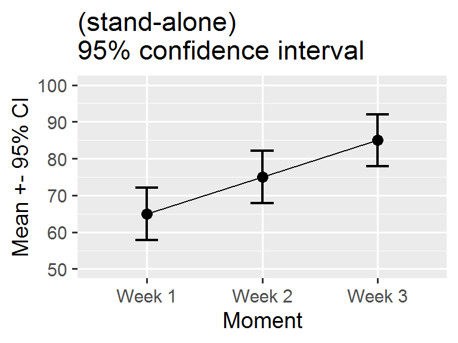

**Figure 1**. Mean scores along with 95% confidence interval per week for a program to stop smoking.

Note that missing data are not handled by `superb`. The cells with NA must be removed or imputed prior to perform the plot.

## Step 1: Decide of the purpose of the plot

In Figure 1 above, did you look at the result of, say, Week 1, in isolation? or did you compare it to the results obtained in the other weeks? The second perspective is actually to look at the **difference** between the results. if such is the case, the error bar shown on this plot are actually misleading because they are too short. The reason for that is further explored in [Vignette 2](https://dcousin3.github.io/superb/articles/Vignette2.html).

In most experiments, one condition is **compared** to other conditions. In that case, we are interested in **pair-wise** differences between means, not by single results in isolation. Yet, the regular confidence intervals are valid only for results in isolation. Whenever you wish to compare a result to other results, to examine differences between conditions (which is, most of the time), you need to adjust the confidence interval lengths so that they remain adequate inference tools.

In `superb`, you obtain an adjustment to error bar length with an option for the purpose of the plot. The default `purpose = "single"` returns stand-alone error bars (as in Figure 1); `purpose = "difference"` returns error bars valid for pair-wise comparisons. The minimum specification for the data frame above would therefore be

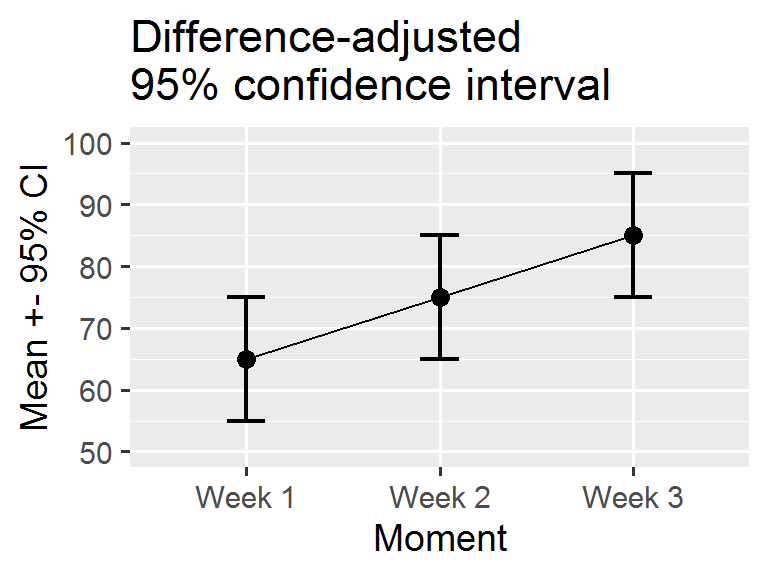

**Figure 2**. Mean scores along with difference-adjusted 95% confidence interval per week for a program to stop smoking.

```r
superbPlot(dta,
    WSFactors = "Moment(3)",
    variables = c("Week 1", "Week 2", "Week 3"),
    adjustments = list(purpose = "difference"),
    plotStyle="line"
    )
```

The first argument is the data.frame, in wide format (here `dta`). The second argument describe the experimental design. Here, there is a single within-subject factor (`WSFactors`), called `Moment`. In within-subject factors, it is necessary to indicate how many level the factor has (here 3). The third argument indicates the columns in the data.frame containing the measurements. Three columns are involved. The name must match the column names in the data.frame. If unsure, check with

```r
head(dta)
```

```
##   Week 1 Week 2 Week 3
## 1     45     50     59
## 2     47     58     64
## 3     53     63     72
## 4     57     64     81
## 5     58     67     86
## 6     61     70     98
```

The argument in which the adjustments will be listed is called `adjustments` which is a list with —for the moment— an adjustment for the purpose of the plot: `purpose = "difference"`. The standalone CI is the default (it can be obtained explicitly with `purpose= "single"`). These two expressions, *single* and *difference*, are from Baguley (2012).

Note that the plot obtained is a `ggplot` object to which additional graphing directives can be added. Figure 2 was actually obtained with these commands:

```r
superbPlot(dta,
    WSFactors = "Moment(3)",
    variables = c("Week 1", "Week 2", "Week 3"),
    statistic = "mean", errorbar = "CI",
    adjustments = list(purpose = "difference"),
    plotStyle="line"
) +
coord_cartesian( ylim = c(50,100) ) +
ylab("Mean +- 95% CI") +
labs(title="Difference-adjusted\n95% confidence interval")+
theme_gray(base_size=14) +
scale_x_discrete(labels=c("1" = "Week 1", "2" = "Week 2", "3"="Week 3"))
```

The graphic directives are applied to the whole plot. The reader is referred to the package `ggplot2` for more on these graphing directives.

## Step 2: Decide how to handle the within-subject measures

Is is known that within-subject designs are generally more powerful at detecting differences. The implication of this is that they afford more statistical power and consequently the error bars should be shorter. The stand-alone CI are oblivious to this fact; it is however possible to inform them that you used a within-subject design.

The method to handle within-subject data comes from the observation that repeated measures tend to be correlated (e.g., Goulet & Cousineau, 2019). Informing the CI of this correlation is a process called **decorrelation**. To this day, there exists three methods for decorrelation:

- `CM`: this method, called from the two authors Cousineau and Morey (Cousineau, 2005; Morey, 2008), will decorrelate the data but each measurement may have different adjustments;
- `LM`: this method, the first developed by Loftus and Masson (1994), will make all the error bars have the same length;
- `CA`: this method, called *correlation-based adjustment* was proposed in Cousineau (2019). As per CM, the error bars can be different in length.

The three methods were compared in Cousineau (2019) and shown to be mathematically based on the same concepts and estimating the same precision. It is therefore a matter of personal preference which one you use.

Figure 2 above will become Figure 3 if you add a decorrelation adjustment:

```
## superb::FYI: The HyunhFeldtEpsilon measure of sphericity per group are  0.545
```

```
## superb::FYI: Some of the groups' data are not spherical. Use error bars with caution.
```

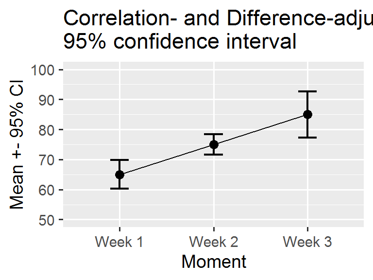

```r
superbPlot(dta,
    WSFactors = "Moment(3)",
    variables = c("Week 1", "Week 2", "Week 3"),
    statistic = "mean", errorbar = "CI",
    adjustments = list(purpose = "difference", decorrelation = "CM"), #new!
    plotStyle="line",
    errorbarParams = list(width = .2)
) +
coord_cartesian( ylim = c(50,100) ) +
ylab("Mean +- 95% CI") +
labs(title="Correlation- and Difference-adjusted\n95% confidence interval")+
theme_gray(base_size=14) +
scale_x_discrete(labels=c("1" = "Week 1", "2" = "Week 2", "3"="Week 3"))
```

Unless you change the options to `options(superb.feedback = 'none')`, the command will issue some additional information. In the present data set, $\varepsilon$ is 0.54 which is low. A Mauchly test of sphericity indicates rejection of sphericity, so interpret the error bars with caution. All the messages issued beginning with `"FYI"` are just information. Hereafter, the warnings are inhibited.

## Step 3: Specify the sampling procedure and the population size

The stand-alone confidence intervals are appropriate when your sample was obtained randomly, a method formally called *Simple Randomize Sampling* (SRS). However, this is not the only sampling method possible. Another commonly employed sampling procedure is cluster sampling (formally *Cluster Randomized Sampling*, CRS). The CRS is the only one (beyond SRS) where the exact adjustment is known (Cousineau & Laurencelle, 2016) and thus SRS (no adjustment) and CRS (adjustments that tend to widen the error bars) are the only two sampling adjustments currently implemented in `superb`.

Other sampling methods includes *Stratified Sampling*, *Snowball Sampling*, *Convenience Sampling*, etc., none of which have a known impact on the precision of the measures.

Also, determine if the population size is finite or infinite. When the population under scrutiny is finite, you may have a sizeable proportion of the population in your sample, which improves precision. In this case, the error bars will be shortened.

These adjustments are implemented in `superb` with additional adjustments, such as

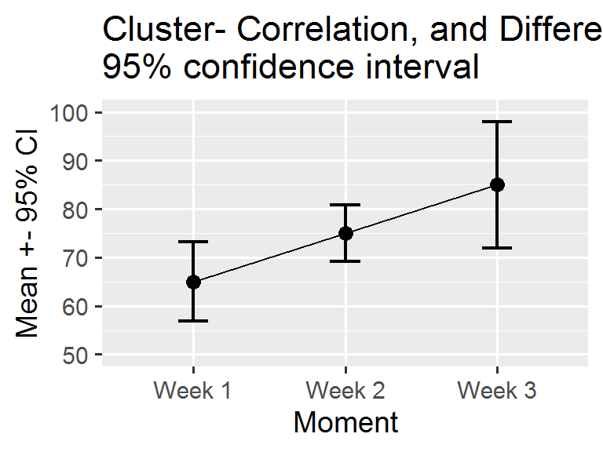

```r
# add (ficticious) cluster membership for each participant in the column "cluster"
dta$cluster <- sort(rep(1:5, 3))

superbPlot(dta,
    WSFactors = "Moment(3)",
    variables = c("Week 1", "Week 2", "Week 3"),
    adjustments = list(purpose = "difference", decorrelation = "CM",
                       samplingDesign = "CRS", popSize = 100),        #new!
    plotStyle = "line",
    clusterColumn = "cluster",  # identify the column containing cluster membership
    errorbarParams = list(width = .2)
) +
coord_cartesian( ylim = c(50,100) ) +
ylab("Mean +- 95% CI") +
labs(title="Cluster- Correlation, and Difference-adjusted\n95% confidence interval")+
theme_gray(base_size=14) +
scale_x_discrete(labels=c("1" = "Week 1", "2" = "Week 2", "3"="Week 3"))
```

As you can see, the adjustments can be obtained with a single option inside the `adjustments` list. They are cumulative, i.e., more than one adjustment can be used, depending on the situation.

# References

Baguley, T. (2012). Calculating and graphing within-subject confidence intervals for ANOVA. *Behavior Research Methods*, *44*, 158–175. https://doi.org/10.3758/s13428-011-0123-7

Cousineau, D. (2005). Confidence intervals in within-subject designs: A simpler solution to Loftus and Masson’s method. *Tutorials in Quantitative Methods for Psychology*, *1*, 42–45. https://doi.org/10.20982/tqmp.01.1.p042

Cousineau, D. (2017). Varieties of confidence intervals. *Advances in Cognitive Psychology*, *13*, 140–155. https://doi.org/10.5709/acp-0214-z

Cousineau, D. (2019). Correlation-adjusted standard errors and confidence intervals for within-subject designs: A simple multiplicative approach. *The Quantitative Methods for Psychology*, *15*, 226–241. https://doi.org/10.20982/tqmp.15.3.p226

Cousineau, D., Goulet, M.-A., & Harding, B. (2021). Summary plots with adjusted error bars: The superb framework with an implementation in R. *Advances in Methods and Practices in Psychological Science*, *in press*, 1–46. https://doi.org/10.1177/25152459211035109

Cousineau, D., & Laurencelle, L. (2016). A correction factor for the impact of cluster randomized sampling and its applications. *Psychological Methods*, *21*, 121–135. https://doi.org/10.1037/met0000055

Goulet, M.-A., & Cousineau, D. (2019). The power of replicated measures to increase statistical power. *Advances in Methods and Practices in Psychological Sciences*, *Online*, 1–15. https://doi.org/10.1177/2515245919849434

Loftus, G. R., & Masson, M. E. J. (1994). Using confidence intervals in within-subject designs. *Psychonomic Bulletin & Review*, *1*, 476–490. https://doi.org/10.3758/BF03210951

Morey, R. D. (2008). Confidence intervals from normalized data: A correction to Cousineau (2005). *Tutorials in Quantitative Methods for Psychology*, *4*, 61–64. https://doi.org/10.20982/tqmp.04.2.p061

Navarro, D. (2015). Learning statistics with R: A tutorial for psychology students and other beginners. (Version 0.5). Retrieved from https://learningstatisticswithr.com/